# homework2

shin jeong min

2018년 9월 28일

## 청소년기의 진로 및 교육경험과 취업의 연관성

1. 선정한 데이터
- 한국교육고용패널
  - 우리나라 청소년의 교육경험과 진학, 진로, 직업세계로의 이행 등을 파악하기 위해 2004년에 시작하여 동일한 표본을 10년이상 추적조사한 종단면 조사이다
  - 출처 : [한국교육고용패널](http://www.krivet.re.kr/ku/ha/kuCAADs.jsp)
2. 데이터 선정 이유
- 청소년기의 교육과 진로지도 및 계획 등의 경험이 성인이 된 후, 노동시장으로의 연결에 어떤 영향을 미치는지 알아보고 이 데이터를 선정하였다.
  - 조사 초반, 학생설문지의 진로지도 및 진로계획 설문지항목을 통해 청소년기의 교육경험과 진로지도경험 여부와 만족도를 알 수 있다.
  - 조사 후반, 통합설문지를 통해 구직활동, 취업여부, 일자리 만족도 등 노동시장에서의 활동을 알 수 있다.

[figure not shown]

학교진로교육실태(2015)

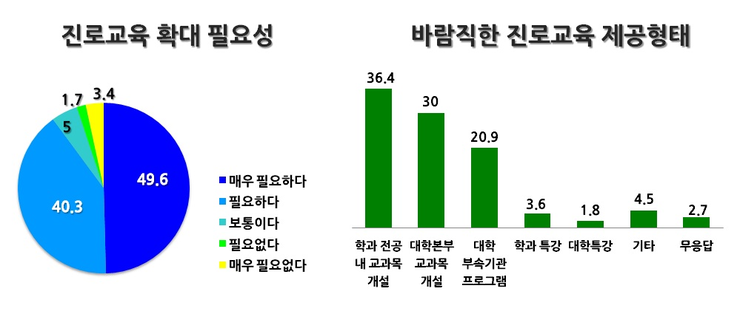

대학진로교육 운영 현황

[figure not shown]

취업

3. 데이터 분석 방향
- 조사대상을 중학교 3학년 코호트로 제한하여 분석한다.
  - 1차년도(2004년)의 중학교 3학년 코호트
  - 3차년도(2006년)의 중학교 3학년 코호트(조사대상의 나이는 18살-고등학교 2학년)
  - 6차년도(2009년)의 중학교 3학년 코호트(조사대상의 나이는 21살)
  - 12차년도(2015년)의 중학교 3학년 코호트(조사대상의 나이는 27살)
- 중학교 3학년 코호트들의 중학교 3학년때와 고등학교 2학년일때 받은 진로지도 경험이 성인이 된 후, 진로결정 및 취업에 어떤 영향을 미쳤는지를 분석한다.
- 이를 통해 진로교육 실태를 파악하고 청소년기의 진로교육의 중요성을 밝히고자 한다.
- 청소년기뿐만 아니라 대학생들의 진료교육 확대 필요성을 파악한다.
- 궁극적으로, 진로교육과 고용간의 연계성과 로학생들의 학교에서 노동시장으로의 이행 과정을 밝히고자 한다.